# Introduction to Network Analysis Tools in R

Michal Bojanowski and Lorien Jasny

Sunbelt-NetSci 2021

# 1 Introduction to this workshop/tutorial

This workshop and tutorial provide an overview of R packages for network analysis. This online tutorial is also designed for self-study, with example code and self-contained data.

- Statnet suite (Krivitsky et al. 2003-2020) including:
  - **network** (Butts 2008, 2021) – storage and manipulation of network data
  - **sna** (Butts 2020) – descriptive statistics and graphics for exploratory network analysis`
- **igraph** (Csardi and Nepusz 2006)
- **tidygraph** (Pedersen 2020) and **ggraph** (Pedersen 2021)
- **graph** (Gentleman et al. 2020) and **Rgraphviz** (Hansen et al. 2021)

and other more specialized packages that provide tools for e.g. particular SNA techniques or visualization, but rely on one of the above for network data storage and manipulation.

## 1.1 Prerequisites

This workshop assumes basic familiarity with **R**, experience with network concepts, terminology and data, and familiarity with the general framework for statistical modeling and inference. While previous experience with ERGMs is not required, some of the topics covered here may be difficult to understand without a strong background in linear and generalized linear models in statistics.

## 1.2 Software installation

Minimally, you will need to install the latest version of **R** [(available here)](https://cran.r-project.org) and the packages listed below. The workshops are conducted using the free version of **RStudio** [(available here)](https://rstudio.com).

The packages required for the workshop can be installed with the following expression:

```r
install.packages(c("network", "sna", "igraph", "tidygraph", "ggraph",
                   "intergraph", "remotes"))
```

```r
remotes::install_bioc("graph")
```

For more information about installing other packages from the Statnet suite can be found on [`statnet` workshop wiki](https://github.com/statnet/Workshops/wiki/Software-Installation-Instructions). In particular, you can install (but do not have to for this tutorial) the whole Statnet suite with:

```r
install.packages('statnet')
```

## 1.3 Necessary data files

- Classroom data is a network within a school class of 26 9-year-olds coming from a larger study of Dolata (2014). The name generator question was “With whom do you like to play with?” The data is available in the following files
  - `classroom-adjacency.csv` with adjacency matrix
  - `classroom-edges.csv` with an edgelist with edge attribute: `liking` – numeric, on the scale 1-5 the extent to which ego likes the alter. This attribute has been randomly generated for illustrative purposes.
  - `classroom-nodes.csv` with node attributes: `female` – logical, gender (`TRUE` for girls); `isei08_m`, `isei08_f` – numeric, social status score of, respectively, mother and father
- Several other datasets contained in the file `introToSNAinR.Rdata`.

Download all the files as a ZIP file `intro-sna-data.zip`.

The code from this tutorial is available as a script too.

## 1.4 Working Directory

Before we go further, make sure R’s Working Directory (WD) is set to the folder where you extracted the data files from the ZIP archive for the workshop. If you’ve not set the working directory, you must do so now by one of:

1. (Recommended) Create an [RStudio Project](https://support.rstudio.com/hc/en-us/articles/200526207-Using-Projects) dedictated to the workshop and unpack the data files there.
2. Use RStudio “Files” tab to navigate to the directory with the workshop files, then click “More” and “Set As Working Directory”:

[figure not shown]

3. You can use `setwd()` to change the working directory as well, like so:

   ```r
   setwd("path/to/folder/with/workshop/files")
   ```

Verify if the WD is set correctly by

1. Looking at the top of the Console window in RStudio, or
2. Use `getwd()`:

   ```r
   getwd() # Check what directory you're in
   ```

   ```
   [1] "C:/Users/mbojanowski/Documents/Teaching/workshop-intro-sna-tools"
   ```

   ```r
   list.files() # Check what's in the working directory
   ```

   ```
    [1] "bibliography.bib"               "captab.html"
    [3] "captab.Rmd"                     "classroom-adjacency.csv"
    [5] "classroom-edges.csv"            "classroom-nodes.csv"
    [7] "docs"                           "edgeList.csv"
    [9] "intro-sna-data.zip"             "intro_tutorial.html"
   [11] "intro_tutorial.R"               "intro_tutorial.Rmd"
   [13] "introToSNAinR.Rdata"            "Makefile"
   [15] "practicals-solved.html"         "practicals.html"
   [17] "practicals.Rmd"                 "publish.R"
   [19] "README.md"                      "relationalData.csv"
   [21] "rstudio-wd.png"                 "vertexAttributes.csv"
   [23] "workshop-intro-sna-tools.Rproj"
   ```

## 1.5 Mitigating function name conflicts

Some packages we are going to demonstrate provide functions with identical names as in other packages. Examples include a function `get.vertex.attribute()` which is defined in packages **network** and **igraph**. Hence, if we load both packages with `library()` it matters which package is loaded last as its version of the function will be used when we write `get.vertex.attribute`.

In particular, note the following function name clashes:

- Between **igraph** and **network**:

  ```
   [1] "%c%"                    "%s%"                    "add.edges"
   [4] "add.vertices"           "delete.edges"           "delete.vertices"
   [7] "get.edge.attribute"     "get.edges"              "get.vertex.attribute"
  [10] "is.bipartite"           "is.directed"            "list.edge.attributes"
  [13] "list.vertex.attributes" "set.edge.attribute"     "set.vertex.attribute"
  ```

- Between **igraph** and **sna**:

  ```
   [1] "betweenness"  "bonpow"       "closeness"    "components"   "degree"
   [6] "dyad.census"  "evcent"       "hierarchy"    "is.connected" "neighborhood"
  [11] "triad.census"
  ```

There are the following strategies to make sure possible conflicts are as painless as possible:

1. Load the packages but do not attach them and always use `::`
2. Load and attach the packages and use `::` for disambiguation.
3. Load the packages and selectively attach and detach them in order to always have only one of them attached.

In this tutorial we had to deal with these conflicts as well. We have opted for strategy (3) because:

- Code blocks will illustrate working with a particular package when without worrying about the conflicts.
- The code examples are clean of `::` namespace directives and hence cleaner to read.

The disadvantage is that

- You will see frequent calls to `library()` and `detach()` at the beginning and end of the subsections to make sure only one intended package is attached at a given time.

# 2 Importing Relational Data

Network data is usually stored as

- Adjacency matrices
- Edge lists
- Edge and vertex data frames

## 2.1 Network

```r
library(network)
library(sna)
```

Read an adjacency matrix (R stores it as a data frame by default). R also won’t permit numbers as column names, although this is fine for rownames.

```r
relations <- read.csv("classroom-adjacency.csv",header=T,row.names=1,stringsAsFactors=FALSE)
relations[1:10,1:10] #look at a subgraph using bracket notation
```

```
     X1003 X1006 X1009 X1012 X1015 X1018 X1021 X1024 X1027 X1030
1003     0     0     0     0     0     1     0     0     0     0
1006     0     0     1     0     0     0     0     0     0     0
1009     0     1     0     0     0     0     0     0     0     0
1012     0     0     0     0     1     0     1     0     0     0
1015     0     0     0     1     0     0     1     0     0     0
1018     0     0     0     0     0     0     0     0     0     0
1021     0     1     1     1     0     0     0     0     0     0
1024     0     0     0     0     0     0     0     0     0     0
1027     0     1     1     0     0     0     0     0     0     0
1030     0     0     1     0     0     0     0     0     0     0
```

We might want to store it as a matrix. Most routines will accept either data format. However, depending on how a function was written, it might require one or the other. The `isSymmetric` function from the `sna` package is one example that requires a matrix rather than a data frame.

```r
relations <- as.matrix(relations) # convert to matrix format
isSymmetric(relations)
```

```
[1] FALSE
```

```r
colnames(relations) <- rownames(relations)
```

Read in some vertex attribute data (okay to leave it as a data frame - in fact converting to a matrix would create problems as matrices can only have strings or numbers, but data frames can have vectors of both)

```r
nodeInfo <- read.csv("classroom-nodes.csv",header=TRUE,stringsAsFactors=FALSE)
head(nodeInfo)
```

```
  name female isei08_m isei08_f
1 1003  FALSE       NA    25.71
2 1006   TRUE    14.64    33.76
3 1009   TRUE    28.48    37.22
4 1012   TRUE    26.64    25.23
5 1015   TRUE    21.24       NA
6 1018  FALSE    23.47    24.45
```

We could also convert it to a network object. This would be useful for (1) storing all data in the same file, (2) a more compact format for large, sparse matrices, or (3) using the data in later analyses where the routines require network objects (e.g. ERGM)

```r
nrelations <- network(relations)
summary(nrelations) # Get an overall summary
```

```
Network attributes:
  vertices = 26
  directed = TRUE
  hyper = FALSE
  loops = FALSE
  multiple = FALSE
  bipartite = FALSE
 total edges = 88
   missing edges = 0
   non-missing edges = 88
 density = 0.1353846

Vertex attributes:
  vertex.names:
   character valued attribute
```

[output cut: 94 more lines]

Here the row and column names have been carried through becasue they were attached to the matrix. We can look at them by using the network variable methods and the shorthand %v%:

```r
list.vertex.attributes(nrelations)
```

```
[1] "na"           "vertex.names"
```

```r
nrelations%v%"vertex.names"
```

```
 [1] "1003" "1006" "1009" "1012" "1015" "1018" "1021" "1024" "1027" "1030"
[11] "1033" "1036" "1039" "1042" "1045" "1048" "1051" "1054" "1057" "1060"
[21] "1063" "1066" "1069" "1072" "1075" "1078"
```

If we wanted to set the names back to the original numbers, we could use these methods as well:

```r
nrelations%v%"vertex.names" <- nodeInfo$name
nrelations%v%"vertex.names"
```

```
 [1] 1003 1006 1009 1012 1015 1018 1021 1024 1027 1030 1033 1036 1039 1042 1045
[16] 1048 1051 1054 1057 1060 1063 1066 1069 1072 1075 1078
```

### 2.1.1 Now with edgelists

Reading in an edgelist and converting it to a network object is also straightforward. Edgelists are useful because they are a smaller, more concise data structure for larger, sparser networks that we typically deal with in social network analysis.

In the newest release of statnet it will automatically read the weight data and store it as “Weight.” If you’re using an older version of statnet, you might need to add two more commands to the `network` command: `ignore.eval=FALSE` and `names.eval="Weight"`.

```r
edgelist<-read.csv("classroom-edges.csv",header=T,stringsAsFactors = F)
head(edgelist)
```

```
  from   to liking
1 1003 1018      3
2 1003 1051      3
3 1003 1072      4
4 1006 1009      5
5 1006 1042      1
6 1006 1057      4
```

```r
edgeNet<-network(edgelist,matrix.type="edgelist")
edgeNet
```

```
 Network attributes:
  vertices = 25
  directed = TRUE
  hyper = FALSE
  loops = FALSE
  multiple = FALSE
  bipartite = FALSE
  total edges= 88
    missing edges= 0
    non-missing edges= 88

 Vertex attribute names:
    vertex.names

 Edge attribute names:
    liking
```

Converting back to an adjacency matrix is simple:

```r
edgeNet[,] ##what's missing?
```

```
     1003 1006 1009 1012 1015 1018 1021 1027 1030 1033 1036 1039 1042 1045 1048
1003    0    0    0    0    0    1    0    0    0    0    0    0    0    0    0
1006    0    0    1    0    0    0    0    0    0    0    0    0    1    0    0
1009    0    1    0    0    0    0    0    0    0    0    0    0    0    0    0
1012    0    0    0    0    1    0    1    0    0    0    0    0    0    0    0
1015    0    0    0    1    0    0    1    0    0    0    0    0    0    0    0
1018    0    0    0    0    0    0    0    0    0    0    0    0    1    0    1
1021    0    1    1    1    0    0    0    0    0    0    0    0    0    0    0
1027    0    1    1    0    0    0    0    0    0    0    0    0    0    0    1
1030    0    0    1    0    0    0    0    0    0    0    0    0    0    0    0
1033    0    0    0    0    0    0    0    0    0    0    0    0    0    0    0
1036    0    1    0    0    0    0    0    0    0    1    0    0    1    0    0
1039    0    0    0    0    0    1    0    0    0    0    0    0    1    0    0
1042    0    1    0    0    0    1    0    0    0    0    0    1    0    0    0
1045    0    0    0    0    0    1    0    0    0    0    0    0    1    0    0
```

[output cut: 37 more lines]

In `network` edges and edge weights are considered separate. This is confusing, but done for a number of reasons. (1) you might want multiple types of weights associated with a given edge, or (2) you might want a weight associated where there isn’t an edge at all.

To see a particular weight, use the edge attribute shorthand %e% and to get the full network with weights, the command `as.sociomatrix.sna`. Note that the `network` command just called the weights by the column name from the csv file.

```r
list.edge.attributes(edgeNet)
```

```
[1] "liking" "na"
```

```r
edgeNet %e% "liking"
```

```
 [1] 3 3 4 5 1 4 1 2 3 5 5 4 3 2 1 2 1 4 3 5 2 2 4 3 4 4 4 3 2 5 3 4 4 3 1 4 2 2
[39] 4 3 2 3 2 1 2 1 1 4 5 2 2 4 3 4 1 1 3 3 2 1 4 4 4 2 5 4 5 3 3 5 4 3 1 5 4 3
[77] 2 3 3 3 2 5 3 1 5 1 1 4
```

```r
as.sociomatrix.sna(edgeNet, "liking")
```

```
     1003 1006 1009 1012 1015 1018 1021 1027 1030 1033 1036 1039 1042 1045 1048
1003    0    0    0    0    0    3    0    0    0    0    0    0    0    0    0
1006    0    0    5    0    0    0    0    0    0    0    0    0    1    0    0
1009    0    2    0    0    0    0    0    0    0    0    0    0    0    0    0
1012    0    0    0    0    5    0    4    0    0    0    0    0    0    0    0
1015    0    0    0    2    0    0    1    0    0    0    0    0    0    0    0
1018    0    0    0    0    0    0    0    0    0    0    0    0    1    0    4
1021    0    2    4    3    0    0    0    0    0    0    0    0    0    0    0
1027    0    4    3    0    0    0    0    0    0    0    0    0    0    0    2
1030    0    0    4    0    0    0    0    0    0    0    0    0    0    0    0
1033    0    0    0    0    0    0    0    0    0    0    0    0    0    0    0
1036    0    4    0    0    0    0    0    0    0    2    0    0    2    0    0
1039    0    0    0    0    0    4    0    0    0    0    0    0    3    0    0
1042    0    2    0    0    0    3    0    0    0    0    0    2    0    0    0
1045    0    0    0    0    0    2    0    0    0    0    0    0    1    0    0
```

[output cut: 37 more lines]

```r
# Detaching the packages
detach(package:sna)
detach(package:network)
```

## 2.2 Igraph

```r
library(igraph)
```

Small Igraph objects can be created using `make_graph()`. You can create network from data using one of the functions from the table below. The table point to functions for:

- creating igraph objects from other R objects
- transforming igraph objects into other R objects

| Object | Object -> Igraph | Igraph -> Object |
| --- | --- | --- |
| Adjacency matrix | `graph_from_adjacency_matrix` | `as_adjacency_matrix` |
| Edge list | `graph_from_edgelist` | `as_edgelist` |
| Data frames | `graph_from_data_frame` | `as_data_frame` |

### 2.2.1 Simple graphs with `make_graph()`

Function `make_graph()` can quickly create small networks. Relational information can be supplied in two ways:

1. As a vector of even number of node IDs. Pairs of adjacent IDs are interpreted as edges:

   ```r
   make_graph( c(1,2, 2,3, 3,4), directed=FALSE)
   ```

   ```
   IGRAPH 6a44d44 U--- 4 3 --
   + edges from 6a44d44:
   [1] 1--2 2--3 3--4
   ```

   ```r
   g1 <- make_graph(~ A - B, B - C:D:E)
   g2 <- make_graph(~ A --+ B, B +-- C, A --+ D:E, B --+ A)
   g2
   ```

   ```
   IGRAPH 6a532bf DN-- 5 5 --
   + attr: name (v/c)
   + edges from 6a532bf (vertex names):
   [1] A->B A->D A->E B->A C->B
   ```

The print-out of `g2` exemplifies how **igraph** summarizes igraph objects:

- First line includes
  - Class of the object (`IGRAPH`)
  - An ID of the object, not of particular interest (see also `?igraph::graph_id`)
  - A set of four slots for letter codes indicating, in order:
    - `U` or `D` if the network is `U`ndirected or `D`irected
    - `N` if the nodes have names
    - `W` if the network is weighted
    - `B` if the network is bipartite
  - Number of nodes
  - Number of edges
- Starting with `+ attr:` list of present attributes, each of the form `nameoftheattribute (x/y)` where
  - `x` informs about the type of an attribute: `v`ertex, `e`dge or `g`raph attribute
  - `y` informs about the mode of an attribute: `n`umeric, `c`haracter, `l`ogical, or e`x`tended (e.g. lists)
- Starting with `+ edges:` a list of (some of) the edges of the network

### 2.2.2 Networks from adjacency matrices

Igraph objects can be created from adjacency matrices with `graph_from_adjacency_matrix()`:

```r
graph_from_adjacency_matrix(relations, mode="directed")
```

```
IGRAPH 6a5bb79 DN-- 26 88 --
+ attr: name (v/c)
+ edges from 6a5bb79 (vertex names):
 [1] 1003->1018 1003->1051 1003->1072 1006->1009 1006->1042 1006->1057
 [7] 1006->1078 1009->1006 1009->1057 1009->1078 1012->1015 1012->1021
[13] 1012->1075 1015->1012 1015->1021 1015->1078 1018->1042 1018->1048
[19] 1018->1051 1018->1060 1018->1072 1021->1006 1021->1009 1021->1012
[25] 1021->1057 1021->1078 1027->1006 1027->1009 1027->1048 1027->1051
[31] 1027->1057 1027->1078 1030->1009 1030->1078 1033->1051 1036->1006
[37] 1036->1033 1036->1042 1039->1018 1039->1042 1042->1006 1042->1018
[43] 1042->1039 1042->1051 1045->1018 1045->1042 1048->1018 1048->1042
+ ... omitted several edges
```

Important arguments:

- `mode` – how to interpret the matrix
  - `"directed"`, `"undirected"`: directed/undirected network
  - `"max"`, `"min"`, `"sum`": determine the number of $i$-$j$ relations that will be created, e.g., `max( m[i,j], m[j,i] )`.
  - `"lower"`, `"upper"`: whether to read only lower/upper triangle of the matrix
- `weighted` – if `TRUE` non-zero values of the matrix are stored in edge attribute `weight`

### 2.2.3 Networks from edge lists

Function `graph_from_edgelist()` expects a two-column matrix

```r
edgelist_matrix <- as.matrix(edgelist[,1:2])
head(edgelist_matrix)
```

```
     from   to
[1,] 1003 1018
[2,] 1003 1051
[3,] 1003 1072
[4,] 1006 1009
[5,] 1006 1042
[6,] 1006 1057
```

Now create the object:

```r
graph_from_edgelist(edgelist_matrix, directed=TRUE)
```

```
IGRAPH 6a6de03 D--- 1078 88 --
+ edges from 6a6de03:
 [1] 1003->1018 1003->1051 1003->1072 1006->1009 1006->1042 1006->1057
 [7] 1006->1078 1009->1006 1009->1057 1009->1078 1012->1015 1012->1021
[13] 1012->1075 1015->1012 1015->1021 1015->1078 1018->1042 1018->1048
[19] 1018->1051 1018->1060 1018->1072 1021->1006 1021->1009 1021->1012
[25] 1021->1057 1021->1078 1027->1006 1027->1009 1027->1048 1027->1051
[31] 1027->1057 1027->1078 1030->1009 1030->1078 1033->1051 1036->1006
[37] 1036->1033 1036->1042 1039->1018 1039->1042 1042->1006 1042->1018
[43] 1042->1039 1042->1051 1045->1018 1045->1042 1048->1018 1048->1042
[49] 1048->1045 1048->1051 1048->1054 1051->1018 1051->1042 1051->1045
+ ... omitted several edges
```

```r
edgelist_matrix_ch <- as.character(edgelist_matrix)
dim(edgelist_matrix_ch) <- dim(edgelist_matrix)
graph_from_edgelist(edgelist_matrix_ch, directed=TRUE)
```

```
IGRAPH 6a77a77 DN-- 25 88 --
+ attr: name (v/c)
+ edges from 6a77a77 (vertex names):
 [1] 1003->1018 1003->1051 1003->1072 1006->1009 1006->1042 1006->1057
 [7] 1006->1078 1009->1006 1009->1057 1009->1078 1012->1015 1012->1021
[13] 1012->1075 1015->1012 1015->1021 1015->1078 1018->1042 1018->1048
[19] 1018->1051 1018->1060 1018->1072 1021->1006 1021->1009 1021->1012
[25] 1021->1057 1021->1078 1027->1006 1027->1009 1027->1048 1027->1051
[31] 1027->1057 1027->1078 1030->1009 1030->1078 1033->1051 1036->1006
[37] 1036->1033 1036->1042 1039->1018 1039->1042 1042->1006 1042->1018
[43] 1042->1039 1042->1051 1045->1018 1045->1042 1048->1018 1048->1042
+ ... omitted several edges
```

This also shows the disadvantage of solely relying on edgelist representation as we are missing one boy who is an isolate.

### 2.2.4 Networks from data frames

Igraph objects can be created from data frames with data on edges and, optionally, on vertices with `graph_from_data_frame`

```r
classroom_kids <- read.csv("classroom-nodes.csv", header=TRUE, colClasses=c(name = "character"))
head(classroom_kids)
```

```
  name female isei08_m isei08_f
1 1003  FALSE       NA    25.71
2 1006   TRUE    14.64    33.76
3 1009   TRUE    28.48    37.22
4 1012   TRUE    26.64    25.23
5 1015   TRUE    21.24       NA
6 1018  FALSE    23.47    24.45
```

```r
classroom_play <- read.csv("classroom-edges.csv", header=TRUE, colClasses = c(from="character", to="character"))
head(classroom_play)
```

```
  from   to liking
1 1003 1018      3
2 1003 1051      3
3 1003 1072      4
4 1006 1009      5
5 1006 1042      1
6 1006 1057      4
```

```r
classroom <- graph_from_data_frame(classroom_play, vertices=classroom_kids,
                                   directed=TRUE)
classroom
```

```
IGRAPH 6a84006 DN-- 26 88 --
+ attr: name (v/c), female (v/l), isei08_m (v/n), isei08_f (v/n),
| liking (e/n)
+ edges from 6a84006 (vertex names):
 [1] 1003->1018 1003->1051 1003->1072 1006->1009 1006->1042 1006->1057
 [7] 1006->1078 1009->1006 1009->1057 1009->1078 1012->1015 1012->1021
[13] 1012->1075 1015->1012 1015->1021 1015->1078 1018->1042 1018->1048
[19] 1018->1051 1018->1060 1018->1072 1021->1006 1021->1009 1021->1012
[25] 1021->1057 1021->1078 1027->1006 1027->1009 1027->1048 1027->1051
[31] 1027->1057 1027->1078 1030->1009 1030->1078 1033->1051 1036->1006
[37] 1036->1033 1036->1042 1039->1018 1039->1042 1042->1006 1042->1018
+ ... omitted several edges
```

```r
detach(package:igraph)
```

## 2.3 Tidygraph

Package **tidygraph** uses **igraph** internally to store network data but provides a “tidy” interface for data manipulation – network data are interfaced as to interconnected data frames (1) nodes and (2) edges. This is very similar to the data structure accepted by `igraph::graph_from_data_frame()` demonstrated above.

```r
library(tidygraph)
```

Objects can be created with:

1. `tbl_graph()` from two data frames, similarly to `igraph::graph_from_data_frame()`

   ```r
   tg_classroom <- tbl_graph(nodes = classroom_kids, edges = classroom_play,
                             directed = TRUE)
   tg_classroom
   ```

   ```
   # A tbl_graph: 26 nodes and 88 edges
   #
   # A directed simple graph with 2 components
   #
   # Node Data: 26 x 4 (active)
     name  female isei08_m isei08_f
     <chr> <lgl>     <dbl>    <dbl>
   1 1003  FALSE      NA       25.7
   2 1006  TRUE       14.6     33.8
   3 1009  TRUE       28.5     37.2
   4 1012  TRUE       26.6     25.2
   5 1015  TRUE       21.2     NA
   6 1018  FALSE      23.5     24.4
   # ... with 20 more rows
   #
   # Edge Data: 88 x 3
      from    to liking
     <int> <int>  <int>
   1     1     6      3
   2     1    17      3
   3     1    24      4
   # ... with 85 more rows
   ```

2. `as_tbl_graph()` which accepts variety of objects: adjacency matrices, igraph, network, ggraph and some more (c.f. the documentation)

   ```r
   # From igraph object created earlier
   tg_classroom2 <- as_tbl_graph(classroom)
   tg_classroom2
   ```

   ```
   # A tbl_graph: 26 nodes and 88 edges
   #
   # A directed simple graph with 2 components
   #
   # Node Data: 26 x 4 (active)
     name  female isei08_m isei08_f
     <chr> <lgl>     <dbl>    <dbl>
   1 1003  FALSE      NA       25.7
   2 1006  TRUE       14.6     33.8
   3 1009  TRUE       28.5     37.2
   4 1012  TRUE       26.6     25.2
   5 1015  TRUE       21.2     NA
   6 1018  FALSE      23.5     24.4
   # ... with 20 more rows
   #
   # Edge Data: 88 x 3
      from    to liking
     <int> <int>  <int>
   1     1     6      3
   2     1    17      3
   3     1    24      4
   # ... with 85 more rows
   ```

   ```r
   # From network object created earlier
   tg_net <- as_tbl_graph(edgeNet)
   tg_net
   ```

   ```
   # A tbl_graph: 25 nodes and 88 edges
   #
   # A directed simple graph with 1 component
   #
   # Node Data: 25 x 1 (active)
     na
     <lgl>
   1 FALSE
   2 FALSE
   3 FALSE
   4 FALSE
   5 FALSE
   6 FALSE
   # ... with 19 more rows
   #
   # Edge Data: 88 x 4
      from    to liking na
     <int> <int>  <int> <lgl>
   1     1     6      3 FALSE
   2     1    16      3 FALSE
   3     1    23      4 FALSE
   # ... with 85 more rows
   ```

### 2.3.1 Working with attributes

In **tidygraph** you can use **dplyr** (Wickham et al. 2021) verbs such as `mutate()`, `select()` etc. once you `activate()` either the `nodes` or `edges` data frame. Here are some examples.

Calculate social status of kid’s family as a minimal value of social statuses of mother and father:

```r
tg_classroom %>%
  activate(nodes) %>%
  mutate(
    status = pmin(isei08_m, isei08_f, na.rm=TRUE)
  )
```

```
# A tbl_graph: 26 nodes and 88 edges
#
# A directed simple graph with 2 components
#
# Node Data: 26 x 5 (active)
  name  female isei08_m isei08_f status
  <chr> <lgl>     <dbl>    <dbl>  <dbl>
1 1003  FALSE      NA       25.7   25.7
2 1006  TRUE       14.6     33.8   14.6
3 1009  TRUE       28.5     37.2   28.5
4 1012  TRUE       26.6     25.2   25.2
5 1015  TRUE       21.2     NA     21.2
6 1018  FALSE      23.5     24.4   23.5
# ... with 20 more rows
#
# Edge Data: 88 x 3
   from    to liking
  <int> <int>  <int>
1     1     6      3
2     1    17      3
3     1    24      4
# ... with 85 more rows
```

Similarly to **dplyr** you can use the pipe operator `%>%` to chain multiple data transformations. Here add a node attribute first, then edge attribute `like5` second:

```r
tg_classroom %>%
  activate(nodes) %>%
  mutate(
    status = pmin(isei08_m, isei08_f, na.rm=TRUE)
  ) %>%
  activate(edges) %>%
  mutate(
    like5 = liking == 5  # TRUE if liking is 5
  )
```

```
# A tbl_graph: 26 nodes and 88 edges
#
# A directed simple graph with 2 components
#
# Edge Data: 88 x 4 (active)
   from    to liking like5
  <int> <int>  <int> <lgl>
1     1     6      3 FALSE
2     1    17      3 FALSE
3     1    24      4 FALSE
4     2     3      5 TRUE
5     2    14      1 FALSE
6     2    19      4 FALSE
# ... with 82 more rows
#
# Node Data: 26 x 5
  name  female isei08_m isei08_f status
  <chr> <lgl>     <dbl>    <dbl>  <dbl>
1 1003  FALSE      NA       25.7   25.7
2 1006  TRUE       14.6     33.8   14.6
3 1009  TRUE       28.5     37.2   28.5
# ... with 23 more rows
```

You can refer to node attributes with `.N()` when computing on edges data frame and refer to edge attributes with `.E()` when computing on the nodes. For example, to add an edge attribute which is `TRUE` if gender of ego and alter match and `FALSE` otherwise we can use `.N()` in the following manner. Function `.N()` returns a the node data frame.

```r
tg_classroom %>%
  activate(edges) %>%
  mutate(
    # Add edge attribute which is TRUE if gender of ego and alter match
    sex_match = .N()$female[from] == .N()$female[to]
  )
```

```
# A tbl_graph: 26 nodes and 88 edges
#
# A directed simple graph with 2 components
#
# Edge Data: 88 x 4 (active)
   from    to liking sex_match
  <int> <int>  <int> <lgl>
1     1     6      3 TRUE
2     1    17      3 TRUE
3     1    24      4 TRUE
4     2     3      5 TRUE
5     2    14      1 FALSE
6     2    19      4 TRUE
# ... with 82 more rows
#
# Node Data: 26 x 4
  name  female isei08_m isei08_f
  <chr> <lgl>     <dbl>    <dbl>
1 1003  FALSE      NA       25.7
2 1006  TRUE       14.6     33.8
3 1009  TRUE       28.5     37.2
# ... with 23 more rows
```

Use `filter()` to select subgraphs:

- Select the subgraph of girls and relations between them:

  ```r
  tg_classroom %>%
    activate(nodes) %>%
    filter(female)
  ```

  ```
  # A tbl_graph: 13 nodes and 41 edges
  #
  # A directed simple graph with 1 component
  #
  # Node Data: 13 x 4 (active)
    name  female isei08_m isei08_f
    <chr> <lgl>     <dbl>    <dbl>
  1 1006  TRUE       14.6     33.8
  2 1009  TRUE       28.5     37.2
  3 1012  TRUE       26.6     25.2
  4 1015  TRUE       21.2     NA
  5 1021  TRUE       21.2     25.2
  6 1027  TRUE       NA       26.0
  # ... with 7 more rows
  #
  # Edge Data: 41 x 3
     from    to liking
    <int> <int>  <int>
  1     1     2      5
  2     1     8      4
  3     1    13      1
  # ... with 38 more rows
  ```

- Select a subgraph of relations for which `liking` is at least 3

  ```r
  tg_classroom %>%
    activate(edges) %>%
    filter(liking >= 3)
  ```

  ```
  # A tbl_graph: 26 nodes and 56 edges
  #
  # A directed simple graph with 3 components
  #
  # Edge Data: 56 x 3 (active)
     from    to liking
    <int> <int>  <int>
  1     1     6      3
  2     1    17      3
  3     1    24      4
  4     2     3      5
  5     2    19      4
  6     3    19      3
  # ... with 50 more rows
  #
  # Node Data: 26 x 4
    name  female isei08_m isei08_f
    <chr> <lgl>     <dbl>    <dbl>
  1 1003  FALSE      NA       25.7
  2 1006  TRUE       14.6     33.8
  3 1009  TRUE       28.5     37.2
  # ... with 23 more rows
  ```

```r
detach(package:tidygraph)
```

## 2.4 graph

```r
library(graph)
```

Package **graph** is implemented using S4 class system (see e.g. the part [“Object oriented programming”](https://adv-r.hadley.nz/oo.html) of Wickham (2019), especially chapter [15 on the S4 system](https://adv-r.hadley.nz/s4.html)). The two main classes of objects are:

- `graphAM` – networks internally stored as adjacency matrices
- `graphNEL` – networks internally stored as adjacency lists (imprecisely called “edge lists” in the documentation). Adjacency list is a list (class of R object) with an element for every node being a vector of adjacent nodes.

Objects can be created with functions with the above names. From adjacency matrices:

```r
gr1 <- graphAM(relations, edgemode = "directed")
gr1
```

```
A graphAM graph with directed edges
Number of Nodes = 26
Number of Edges = 88
```

To demonstrate `graphNEL` we have to create an adjacency list first. We can create it from adjacency matrix `relations` like so:

```r
adjlist <- apply(relations, 1, function(r) rownames(relations)[which(r == 1)])
head(adjlist) # initial elements of the adj. list
```

```
$`1003`
[1] "1018" "1051" "1072"

$`1006`
[1] "1009" "1042" "1057" "1078"

$`1009`
[1] "1006" "1057" "1078"

$`1012`
[1] "1015" "1021" "1075"

$`1015`
[1] "1012" "1021" "1078"

$`1018`
[1] "1042" "1048" "1051" "1060" "1072"
```

… and now the object:

```r
gr2 <- graphNEL(
  nodes = classroom_kids$name, # names of the nodes
  edgeL = adjlist, # adjacency list of node names
  edgemode = "directed"
)
gr2
```

```
A graphNEL graph with directed edges
Number of Nodes = 26
Number of Edges = 88
```

Both types of objects `graphAM` and `graphNEL` can store edge and node attributes. There are separate functions `edgeData()` and `nodeData()` for setting and accessing edge/node attributes. For example to add `female` attribute we need to:

```r
# Set the default value, say FALSE
nodeDataDefaults(gr2, attr="female") <- FALSE
# Assign the values
nodeData(gr2, n = classroom_kids$name, attr="female") <- classroom_kids$female
```

Working with edge attributes look similar, but uses function `edgeData()` like so:

```r
edgeDataDefaults(gr2, attr = "liking") <- as.numeric(NA)
edgeData(gr2,
         from = classroom_play$from,
         to = classroom_play$to,
         attr = "liking") -> classroom_play$liking
```

```r
detach(package:graph)
```

# 3 Converting objects

Use **intergraph** (Bojanowski 2015) to convert data objects between **igraph** and **network** representations.

```r
# igraph -> network
classroom_network <- intergraph::asNetwork(classroom)

# network -> igraph
classroom_igraph <- intergraph::asIgraph(classroom_network)

classroom_network
```

```
 Network attributes:
  vertices = 26
  directed = TRUE
  hyper = FALSE
  loops = FALSE
  multiple = FALSE
  bipartite = FALSE
  total edges= 88
    missing edges= 0
    non-missing edges= 88

 Vertex attribute names:
    female isei08_f isei08_m vertex.names

 Edge attribute names:
    liking
```

```r
classroom_igraph
```

```
IGRAPH 6b8f780 D--- 26 88 --
+ attr: female (v/l), isei08_f (v/n), isei08_m (v/n), na (v/l),
| vertex.names (v/c), liking (e/n), na (e/l)
+ edges from 6b8f780:
 [1]  1-> 6  1->17  1->24  2-> 3  2->14  2->19  2->26  3-> 2  3->19  3->26
[11]  4-> 5  4-> 7  4->25  5-> 4  5-> 7  5->26  6->14  6->16  6->17  6->20
[21]  6->24  7-> 2  7-> 3  7-> 4  7->19  7->26  9-> 2  9-> 3  9->16  9->17
[31]  9->19  9->26 10-> 3 10->26 11->17 12-> 2 12->11 12->14 13-> 6 13->14
[41] 14-> 2 14-> 6 14->13 14->17 15-> 6 15->14 16-> 6 16->14 16->15 16->17
[51] 16->18 17-> 6 17->14 17->15 17->16 17->18 18-> 6 18->13 18->16 18->17
[61] 18->24 19-> 3 19->26 20-> 1 20-> 6 20->14 20->17 21-> 2 21->14 21->22
+ ... omitted several edges
```

All the attributes are copied properly.

Use `igraph::as_graphnel()` and `igraph::graph_from_graphnel()` for **igraph** <-> **graph** conversions.

# 4 Capabilities of objects in different packages

[output not shown]

<sup>*1*</sup> Package 'graph'. <sup>*2*</sup> Networks with edges connecting sets of vertices. <sup>*3*</sup> Networks with multiple edges in the same dyad.

# 5 Visualization

## 5.1 Network

```r
library(network)
library(sna)
```

We can plot matrices using the `gplot` routine from the `sna` package:

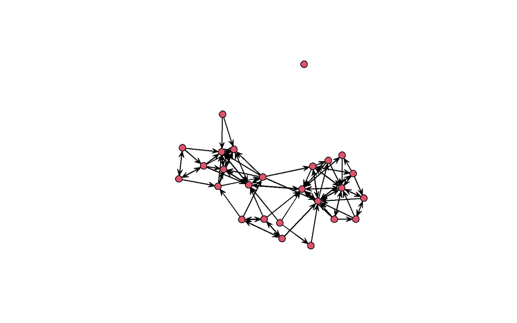

```r
gplot(relations) # Requires sna
```

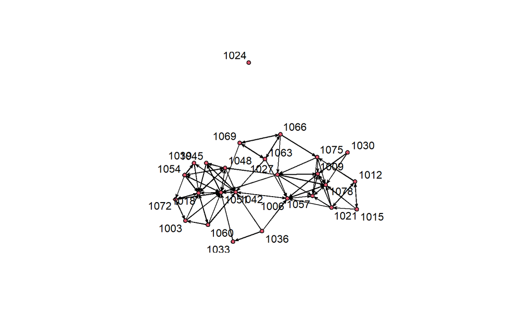

```r
plot(nrelations,displaylabels=T) # Plot with names
```

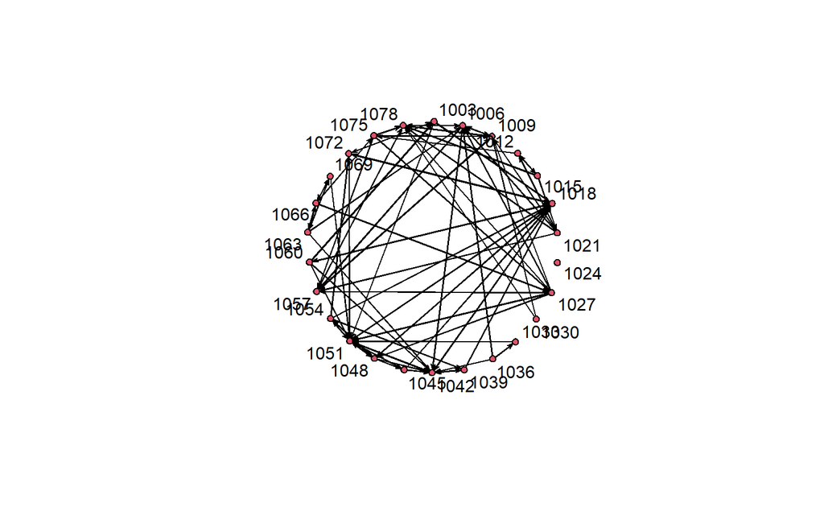

```r
plot(nrelations,displaylabels=T,mode="circle") # A less useful layout...
```

More layout options are included in the `sna` package for `gplot`. Here’s one that selects a node and tries to arrange the other nodes around it as a bullseye.

[figure not shown]

```r
gplot(relations,mode="target")
```

Let’s color the nodes in gender-stereotypic colors, and increase the size of the nodes

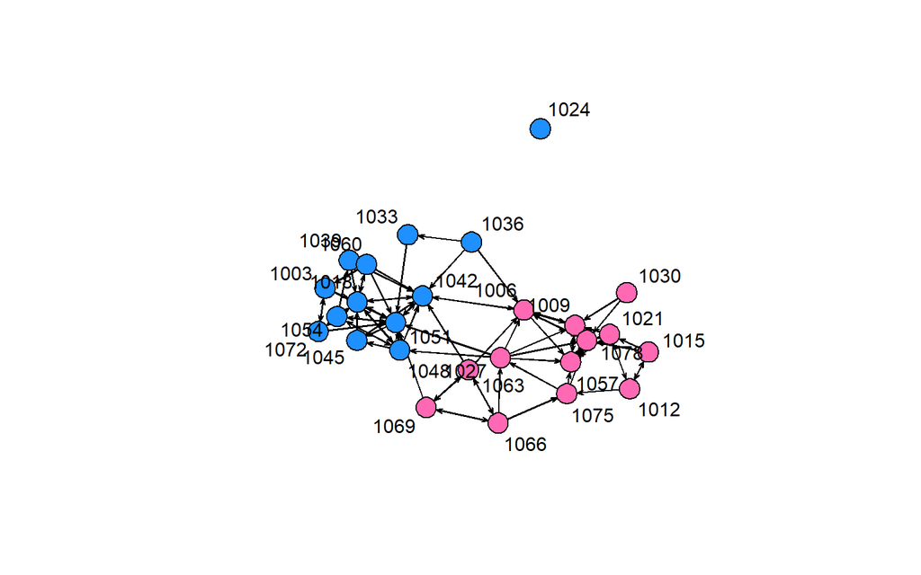

```r
nodeColors<-ifelse(nodeInfo$female,"hotpink","dodgerblue")
plot(nrelations,displaylabels=T,vertex.col=nodeColors,vertex.cex=3)
```

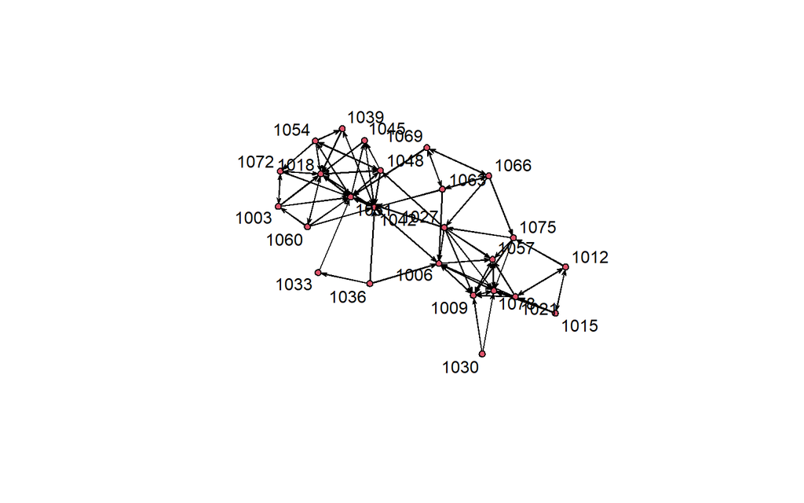

```r
plot(edgeNet,displaylabels=T) ##what's missing?
```

[figure not shown]

```r
plot(edgeNet,displaylabels=T,edge.lwd=5*edgeNet%e%"question")
```

We can now look at slightly more complicated data in the supplied dataset. Plot the contiguity among nations in 1993 (from the Correlates of War (CoW)1 project)

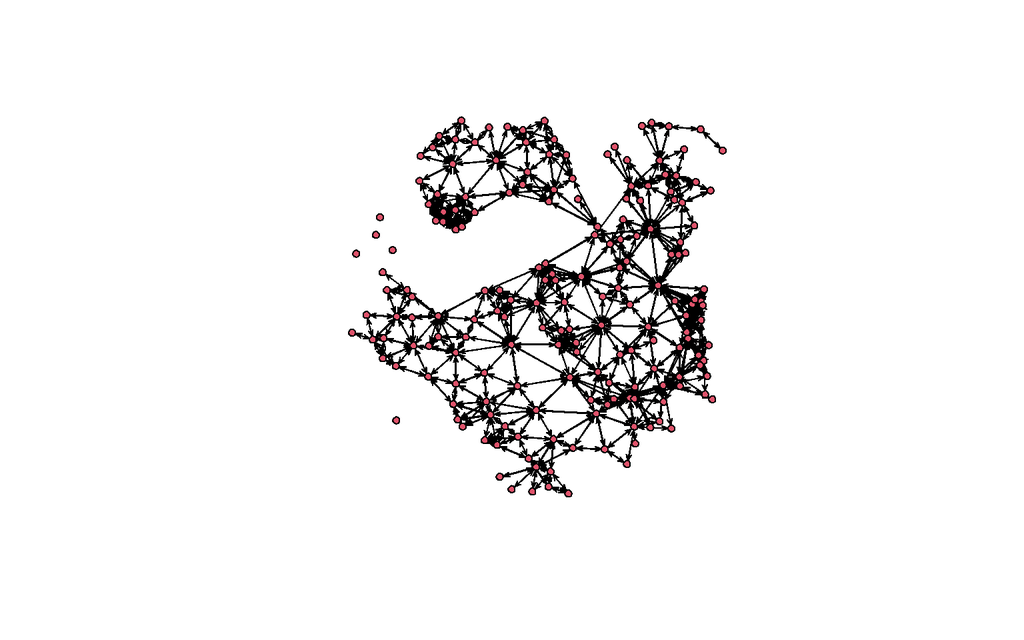

```r
load("introToSNAinR.Rdata")
gplot(contig_1993) # The default visualization
```

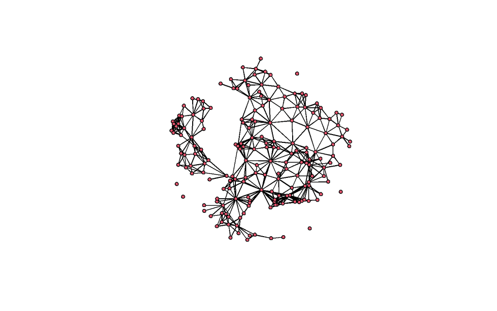

```r
gplot(contig_1993, usearrows=FALSE) # Turn off arrows manually
```

Here’s an example of directed data|militarized interstate disputes (MIDs) for 1993, with added labels

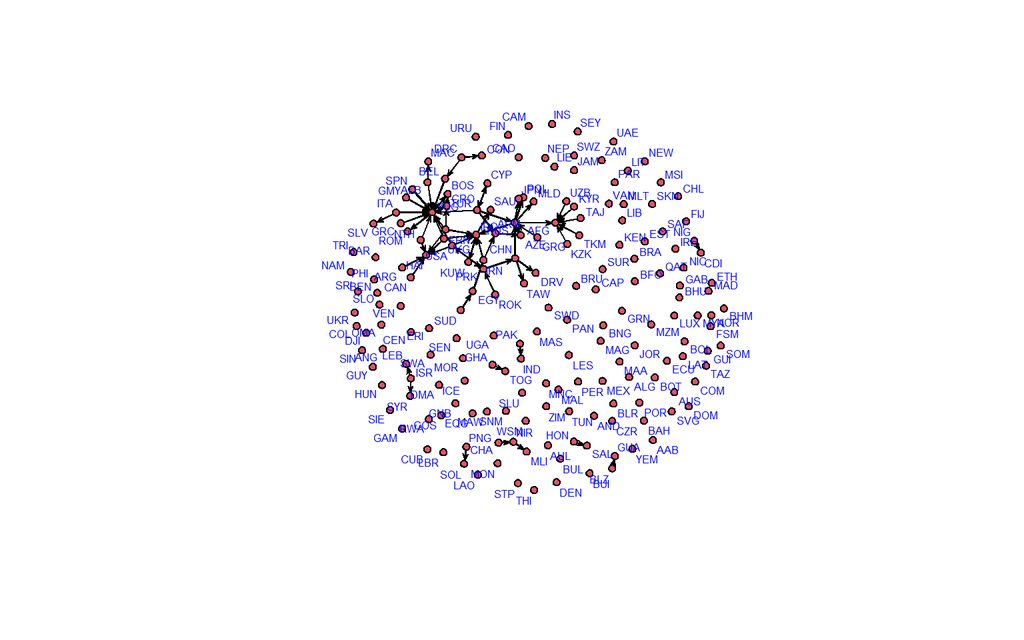

```r
gplot(mids_1993,label.cex=0.5,label.col="blue",displaylabels=TRUE)
```

All those isolates can get in the way. We can suppress them using `displayisolates`

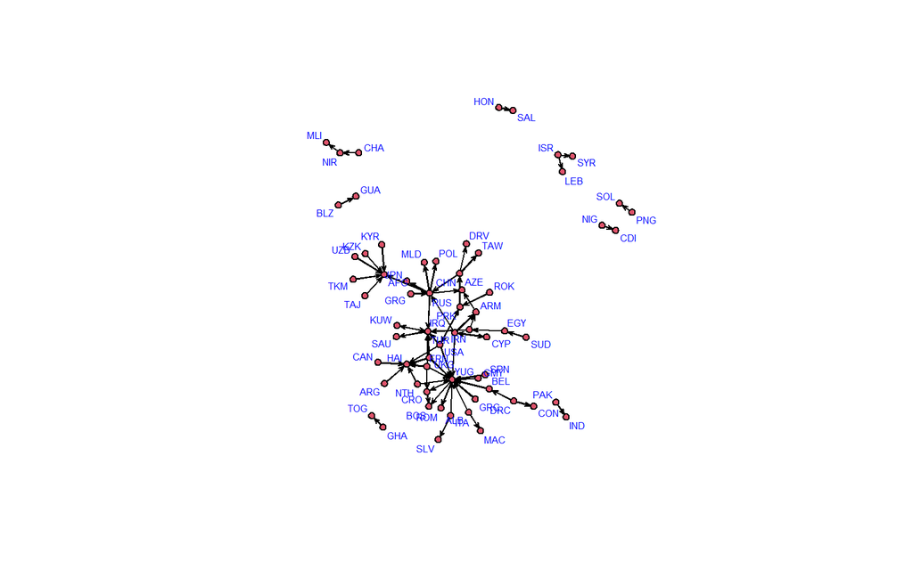

```r
gplot(mids_1993,label.cex=0.5,label.col="blue",displaylabels=TRUE,displayisolates=FALSE)
```

When a layout is generated, the results can be saved for later reuse. Here we use a spring-embedded algorithm on the global contiguity plot to place the nodes and then plot the edges from the militarized interstate dispute network. It’s very approximate, but generally shorter edges are attacks between contiguous or neigbouring countries and longer edges are between farther away countries.

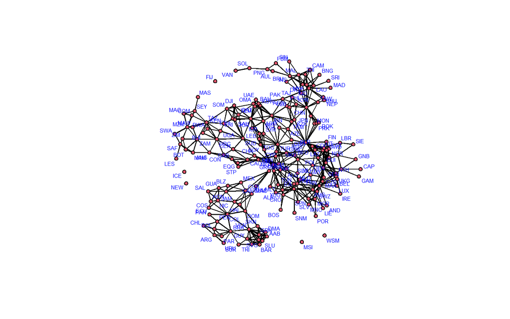

```r
coords <- gplot(contig_1993,gmode="graph",label=colnames(contig_1993[,]),label.cex=0.5,label.col="blue") # Capture the magic of the moment
```

```r
head(coords) # Show the vertex coordinates
```

```
             x         y
[1,]  6.799985 -10.01962
[2,] -0.207204 -18.14538
[3,] -2.484962 -22.21038
[4,] -5.752779 -20.44399
[5,] -8.811638 -27.94802
[6,] -5.929980 -31.39437
```

Saved (or a priori) layouts can be used via the coord argument

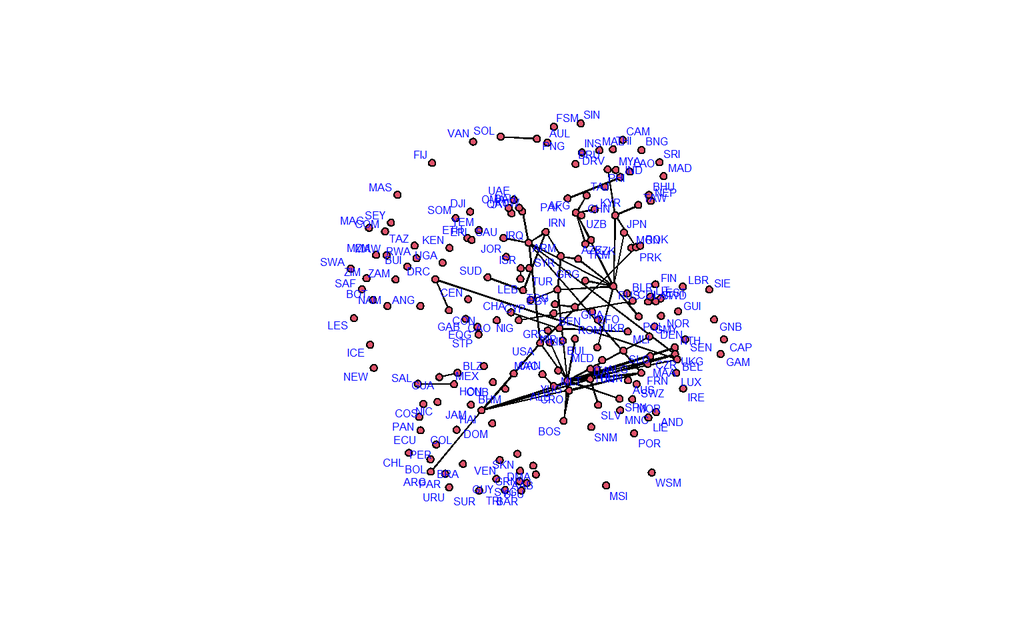

```r
gplot(mids_1993,gmode="graph",label=colnames(contig_1993[,]),label.cex=0.5,label.col="blue",coord=coords)
```

When the default settings are insuficient, interactive mode allows for tweaking. This is a bit clunky and not run here, but can be very useful for getting a specific image exactly correct. We haven’t run it here, but you can play around with it later.

```r
coords <- gplot(contig_1993, interactive=TRUE) # Modify and save
gplot(contig_1993,coord=coords,displaylabels=TRUE,gmode="graph",label.cex=0.5,label.col="blue") # Should reproduce the modified layout
```

```r
# Detaching the packages
detach(package:sna)
detach(package:network)
```

## 5.2 Igraph

```r
library("igraph")
```

Network visualization is performed using `plot` function.

With default settings it looks like

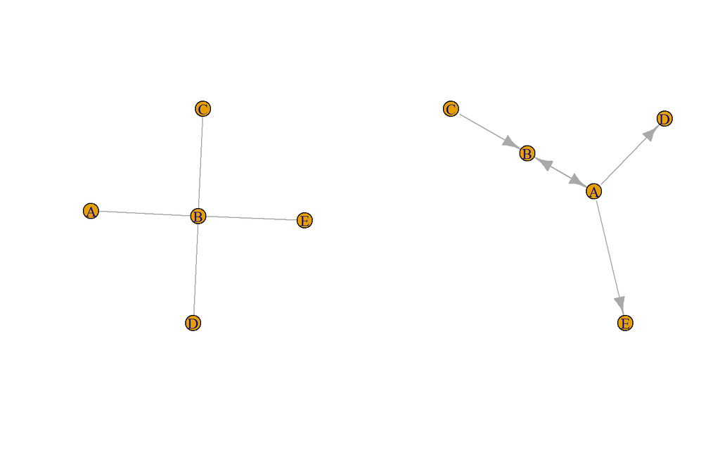

```r
plot(g1)
plot(g2)
```

Example plots using the `classroom` data:

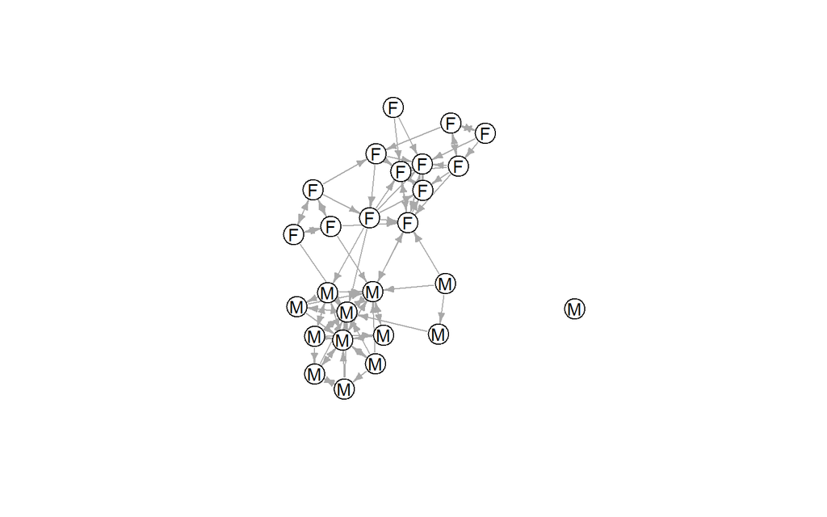

```r
plot(
  classroom,
  layout=layout_with_fr,
  vertex.color="white",
  vertex.size=15,
  edge.arrow.size=0.5,
  vertex.label.color="black",
  vertex.label.family="sans",
  vertex.label=ifelse(V(classroom)$female, "F", "M")
)
```

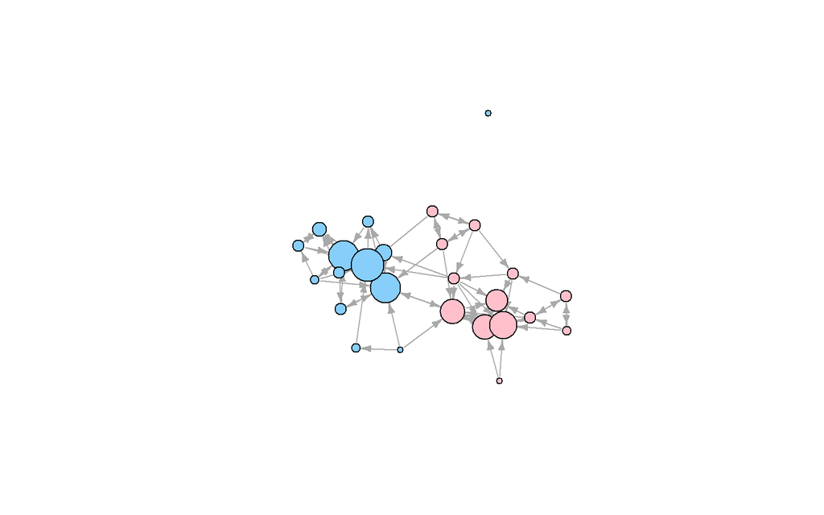

```r
plot(
  classroom,
  layout=layout_with_fr,
  vertex.label=NA,
  vertex.size=scales::rescale(degree(classroom, mode="in"), c(5, 25)),
  edge.arrow.size=0.5,
  vertex.color=ifelse(V(classroom)$female, "pink", "lightskyblue")
)
```

```r
detach(package:igraph)
```

## 5.3 A note on layouts

Notable layouts in **sna**:

- target

Notable layouts in **igraph**:

- sugiyama

Package **graphlayouts**:

- stress
- focus

# 6 Description

## 6.1 Network

```r
library(network)
library(sna)
```

The network package has many routines to describe the data. Dyads give the number of possible edges, so $n*(n-1)$ for a directed graph, and $\frac{n*(n-1)}{2}$ for undirected graphs. The edgecount will give the number of actual edges, and the size the number of nodes.

```r
network.dyadcount(nrelations) # How many dyads?
```

```
[1] 650
```

```r
network.edgecount(nrelations) # How many edges are present?
```

```
[1] 88
```

```r
network.size(nrelations) # How large is the network?
```

```
[1] 26
```

Going back to the Correlates of War data, we can look at our centrality measures. Freeman degree is also called total degree and is the sum of the indegrees and outdegrees. One degree centrality function is used for all three with a default of Freeman degree. The input for `cmode` determines which kind of degree is calculated.

```r
degree(mids_1993) # Default: total degree
```

```
  [1]  5  1  0  0  6  0  0  0  0  0  0  0  0  0  0  0  1  1  1  1  0  0  0  0  0
 [26]  0  0  0  0  0  0  0  0  1  0  3  0  2  2  0  4  0  0  0  1  0  0  1  1  0
 [51]  0  0  0  2  0  0  2  1  3 14  2  1  1  2  0  1  1  9  0  0  0  0  0  3  1
 [76]  2  0  0  0  0  0  0  0  0  0  0  1  0  0  0  2  1  0  0  0  0  1  1  0  1
[101]  0  0  1  1  2  0  0  0  0  0  0  0  0  0  0  0  0  0  0  0  0  0  0  0  0
[126]  0  0  0  0  0  0  0  1  3  5  8  2  1  1  0  2  1  0  2  0  0  0  0  6  1
[151]  1  1  1  1  4  0  1  4  1  1  1  0  1  0  0  0  0  0  0  0  0  1  0  0  0
[176]  0  0  0  1  0  0  1  0  0  0  0
```

```r
ideg <- degree(mids_1993, cmode="indegree") # Indegree for MIDs
odeg <- degree(mids_1993, cmode="outdegree") # Outdegree for MIDs
all(degree(mids_1993) == ideg+odeg) # In + out = total?
```

```
[1] TRUE
```

Once centrality scores are computed, we can handle them using standard R methods. Here, the dashed line indicates where on the plot outgoing attacks would equal incoming attacks (y=x); countries above this line are net agressors, and countries below are net defenders.

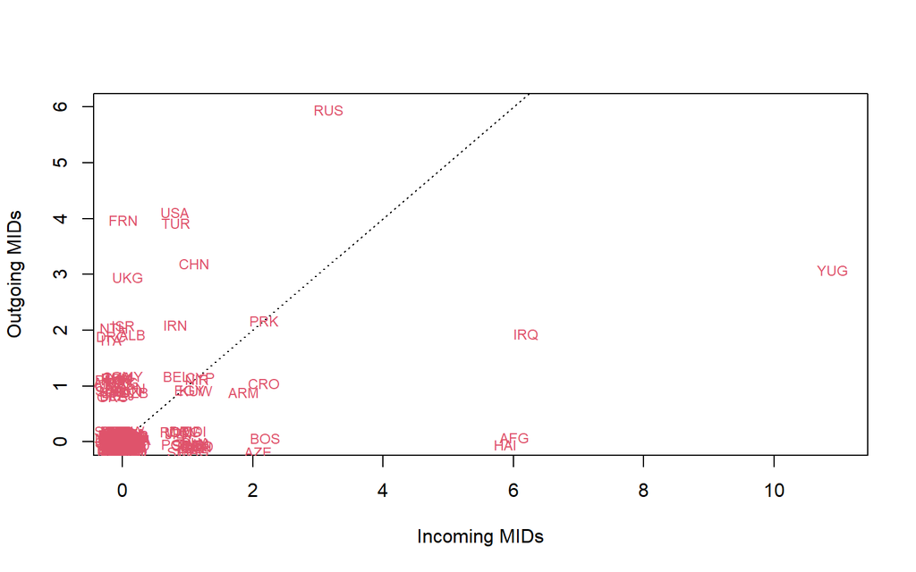

```r
plot(ideg,
     odeg,
     type="n",
     xlab="Incoming MIDs",
     ylab="Outgoing MIDs") # Plot ideg by odeg

abline(0, 1, lty=3)

text(jitter(ideg),
     jitter(odeg),
     network.vertex.names(contig_1993),
     cex=0.75,
     col=2)
```

Plot simple histograms of the degree distributions. These can be quite useful to get a sense of how skewed the network is.

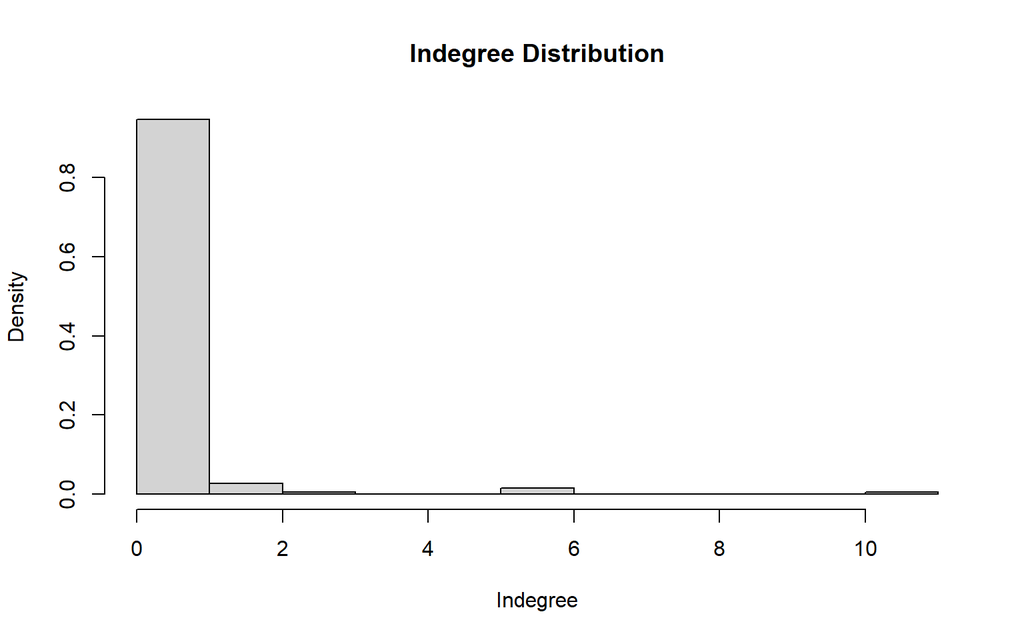

```r
hist(ideg,
     xlab="Indegree",
     main="Indegree Distribution",
     prob=TRUE)
```

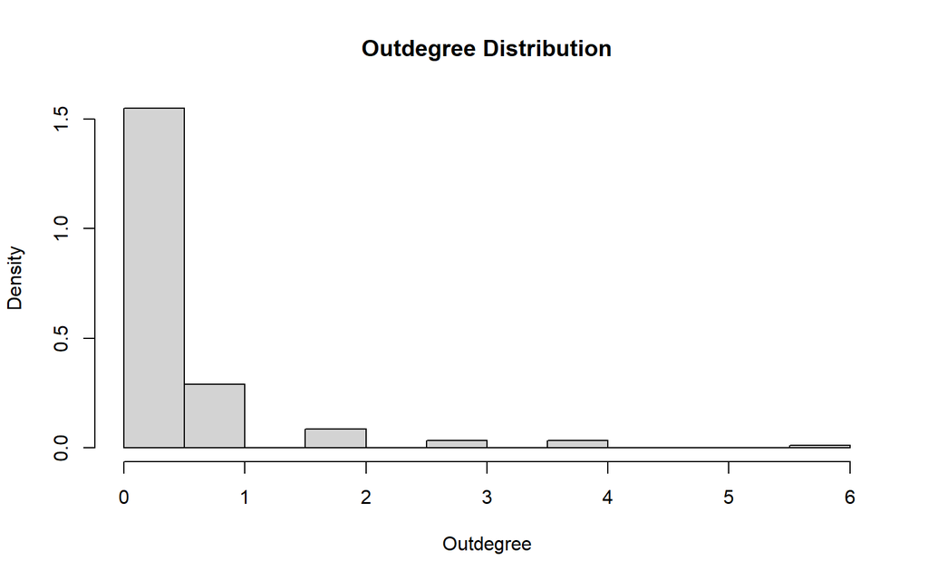

```r
hist(odeg,
     xlab="Outdegree",
     main="Outdegree Distribution",
     prob=TRUE)
```

Centrality scores can also be used with other sna routines, e.g., gplot(). Here we’ve used the color functionality in rgb to shade each node by how much of an agressor (red) and defender (blue) compared to the other countries each node is.

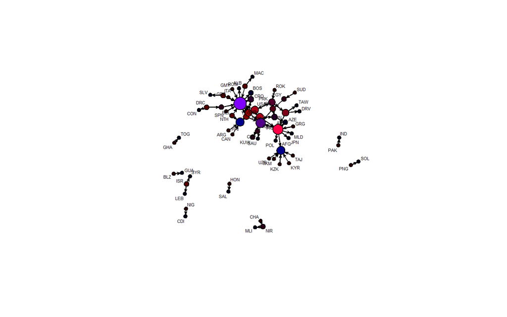

```r
gplot(mids_1993,
      vertex.cex=(ideg+odeg)^0.5,
      vertex.sides=50,
      label.cex=0.4,
      vertex.col=rgb(odeg/max(odeg),0,ideg/max(ideg)),
      displaylabels=TRUE,
      displayisolates=FALSE)
```

Betweenness and closeness are also popular measures

```r
bet <- betweenness(contig_1993,
                   gmode="graph") # Geographic betweenness

bet
```

```
  [1] 4997.6666667    0.0000000 1780.9333333 2063.4119048  445.9444444
  [6] 2237.2984127  550.4444444   29.2618687    1.4553030    0.2916667
 [11]    2.2191919    2.2191919    2.3441919    0.2916667  387.7916667
 [16]  640.0412698    1.0079365  262.8190476  197.6650794    0.4444444
 [21]  102.2246032   36.8031746    0.0000000 1359.0634921 1206.5426768
 [26]   44.5261544    2.2166667    0.0000000  242.5166667  760.7691198
 [31]    5.3095238    0.0000000    0.5833333    5.8928571    0.0000000
 [36]   65.6519270    0.0000000    8.7941824    1.0000000    0.0000000
 [41] 1558.2179920    0.0000000    0.0000000  123.6114706  244.8535495
 [46]    0.0000000    0.0000000 1216.0722311  135.5883869  287.1149376
 [51]  149.1209944    3.8980482   19.8155403 1046.8181481    0.0000000
 [56]   11.4371615   11.9421356    1.3251984  109.5508382  157.8191065
 [61]    0.0000000   12.4300337  526.2041909    9.9764069  132.2971043
 [66]    0.0000000  137.1758265 7944.2773019    3.3530897   10.4082027
 [71]    9.9320123  639.1920120    3.9538070    4.1910347   24.4580713
```

[output cut: 23 more lines]

Closeness can be a bit tricky for disconnected graphs, but there are alternative definitions that fix some problems - see the help file for a discussion.

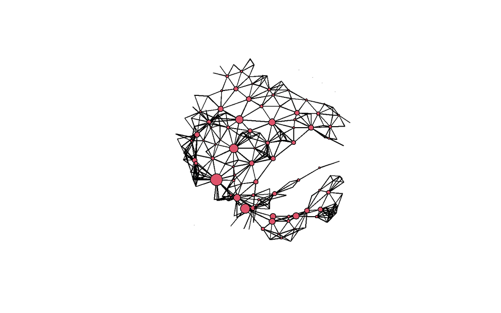

```r
gplot(contig_1993,
      vertex.cex=sqrt(bet)/25,
      gmode="graph") # Use w/gplot
```

```r
clo <- closeness(contig_1993) # Geographic closeness
clo # A large world after all?
```

```
  [1] 0 0 0 0 0 0 0 0 0 0 0 0 0 0 0 0 0 0 0 0 0 0 0 0 0 0 0 0 0 0 0 0 0 0 0 0 0
 [38] 0 0 0 0 0 0 0 0 0 0 0 0 0 0 0 0 0 0 0 0 0 0 0 0 0 0 0 0 0 0 0 0 0 0 0 0 0
 [75] 0 0 0 0 0 0 0 0 0 0 0 0 0 0 0 0 0 0 0 0 0 0 0 0 0 0 0 0 0 0 0 0 0 0 0 0 0
[112] 0 0 0 0 0 0 0 0 0 0 0 0 0 0 0 0 0 0 0 0 0 0 0 0 0 0 0 0 0 0 0 0 0 0 0 0 0
[149] 0 0 0 0 0 0 0 0 0 0 0 0 0 0 0 0 0 0 0 0 0 0 0 0 0 0 0 0 0 0 0 0 0 0 0 0 0
[186] 0
```

```r
closeness(contig_1993,cmode="suminvundir")
```

```
  [1] 0.2933419 0.2186251 0.2515980 0.2615079 0.2263751 0.2389878 0.2335823
  [8] 0.1879666 0.1906693 0.1843630 0.1906693 0.1906693 0.1933720 0.1843630
 [15] 0.2079823 0.2450215 0.2098887 0.2169157 0.2227715 0.1890634 0.2102346
 [22] 0.2030274 0.1798585 0.2300544 0.2318562 0.1956243 0.1650359 0.1753540
 [29] 0.1879666 0.2059846 0.1677386 0.1614323 0.1560269 0.1668377 0.1587296
 [36] 0.2696933 0.2283376 0.2669906 0.2660897 0.2579816 0.3151094 0.2524024
 [43] 0.2184277 0.2819562 0.2747447 0.2287881 0.2089489 0.3321321 0.3088889
 [50] 0.2905148 0.2698734 0.2568104 0.2662698 0.3195903 0.2252660 0.2704912
 [57] 0.2635736 0.2438438 0.2689790 0.2696096 0.2074174 0.2551051 0.3184234
 [64] 0.2847297 0.2816860 0.2368876 0.2830373 0.3847555 0.2901502 0.2955556
 [71] 0.2928529 0.3213320 0.2775247 0.2775676 0.3015122 0.3166281 0.2795066
 [78] 0.2955556 0.2901502 0.3186186 0.0000000 0.1664139 0.2078757 0.1722698
 [85] 0.2078757 0.1664139 0.2574732 0.2130108 0.2329043 0.2401308 0.2904397
 [92] 0.2136736 0.2125604 0.2360317 0.1766585 0.1688464 0.2116208 0.2062154
 [99] 0.2553754 0.2564565 0.2218396 0.2577499 0.2858451 0.2302800 0.2702724
[106] 0.2540562 0.2578829 0.2575623 0.2168888 0.2195915 0.2580051 0.2421943
[113] 0.2638288 0.2544595 0.2290188 0.2222053 0.2396301 0.1955836 0.2041872
[120] 0.1892055 0.1984279 0.1491523 0.1924305 0.1738151 0.1747160 0.2030611
[127] 0.1616358 0.2057638 0.2347254 0.3060768 0.2867074 0.3400837 0.3156306
[134] 0.3292664 0.3650965 0.2974775 0.3229665 0.2809459 0.2728378 0.2579344
[141] 0.2868018 0.3105405 0.2715315 0.2577864 0.2664736 0.2664736 0.2601673
[148] 0.2866924 0.2848005 0.2976963 0.2533719 0.2542728 0.2411712 0.3125997
[155] 0.3420592 0.2798906 0.2476190 0.2852960 0.2852960 0.2956564 0.2888739
[162] 0.2476190 0.2957400 0.2138846 0.2636551 0.2102810 0.2102810 0.2476190
[169] 0.2353260 0.2115637 0.2548263 0.2618533 0.2398305 0.1887194 0.2061583
[176] 0.2618533 0.2465873 0.1882690 0.1945753 0.0000000 0.1339852 0.1593136
[183] 0.0000000 0.0000000 0.1882690 0.0000000
```

From centrality to centralization. Here we nest commands - the `cmode` input is sent to the `degree` function.

```r
centralization(mids_1993, degree, cmode="indegree") # Do MIDs concentrate?
```

```
[1] 0.05773557
```

```r
centralization(contig_1993, evcent) # Eigenvector centralization
```

```
[1] 0.3376634
```

```r
gden(mids_1993) # Density
```

```
[1] 0.002034292
```

The MAN distribution is quite useful; it lists the number of Mutal, Assymetric, and Null ties in a given graph:

```r
dyad.census(mids_1993)
```

```
     Mut Asym  Null
[1,]   3   64 17138
```

```r
dyad.census(contig_1993)
```

```
     Mut Asym  Null
[1,] 534    0 16671
```

```r
grecip(mids_1993) # Dyadic reciprocity
```

```
      Mut
0.9962802
```

```r
grecip(mids_1993, measure="edgewise") # Edgewise reciprocity
```

```
       Mut
0.08571429
```

Transitivity is the proportion of paths i–>j–>k where the i–>k edge is also present.

```r
gtrans(mids_1993) # Transitivity
```

```
[1] 0.02409639
```

```r
# Detaching the packages
detach(package:sna)
detach(package:network)
```

## 6.2 Igraph

```r
library("igraph")
summary(g1)
```

```
IGRAPH 6a52900 UN-- 5 4 --
+ attr: name (v/c)
```

```r
ecount(g1)      # number of edges
```

```
[1] 4
```

```r
vcount(g1)      # number of vertices
```

```
[1] 5
```

```r
is.directed(g1) # is the network directed?
```

```
[1] FALSE
```

Graph density and reciprocity

Density = proportion of exisintg edges

```r
edge_density(classroom)
```

```
[1] 0.1353846
```

Reciprocity = proportion of mutual connections

```r
g <- make_graph(c(1,2, 2,3, 3,2), n = 3)
reciprocity(g)
```

```
[1] 0.6666667
```

```r
reciprocity(g, mode="ratio")
```

```
[1] 0.5
```

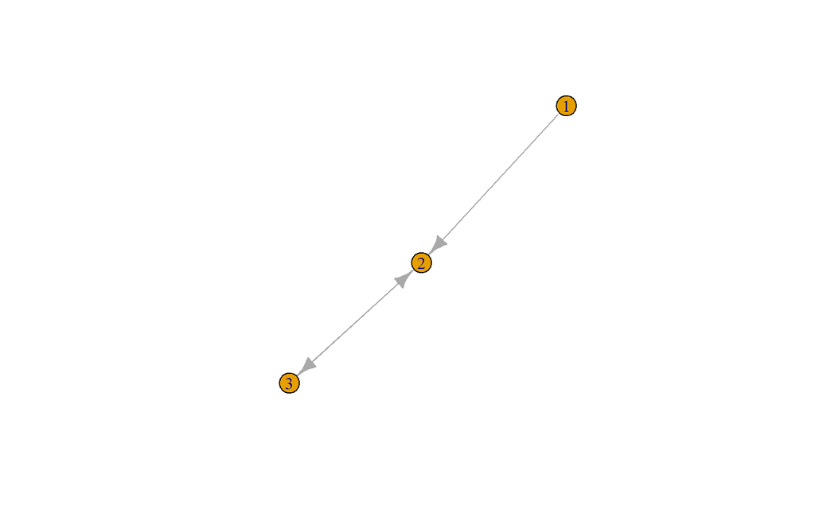

Vertex degrees

Calculating in-/out-/total degrees

```r
degree(classroom)
```

```
1003 1006 1009 1012 1015 1018 1021 1024 1027 1030 1033 1036 1039 1042 1045 1048
   5   11   10    5    4   14    7    0    8    2    2    3    4   13    4    9
1051 1054 1057 1060 1063 1066 1069 1072 1075 1078
  15    7    8    5    6    6    5    6    6   11
```

```r
degree(classroom, mode="in")
```

```
1003 1006 1009 1012 1015 1018 1021 1024 1027 1030 1033 1036 1039 1042 1045 1048
   2    7    7    2    1    9    2    0    2    0    1    0    2    9    2    4
1051 1054 1057 1060 1063 1066 1069 1072 1075 1078
  10    2    6    1    2    2    2    3    2    8
```

```r
degree(classroom, mode="out")
```

```
1003 1006 1009 1012 1015 1018 1021 1024 1027 1030 1033 1036 1039 1042 1045 1048
   3    4    3    3    3    5    5    0    6    2    1    3    2    4    2    5
1051 1054 1057 1060 1063 1066 1069 1072 1075 1078
   5    5    2    4    4    4    3    3    4    3
```

Degree distribution

Fraction of nodes with given degree

```r
degree_distribution(classroom)
```

```
 [1] 0.03846154 0.00000000 0.07692308 0.03846154 0.11538462 0.15384615
 [7] 0.15384615 0.07692308 0.07692308 0.03846154 0.03846154 0.07692308
[13] 0.00000000 0.03846154 0.03846154 0.03846154
```

Centrality

```r
betweenness(classroom)
```

```
       1003        1006        1009        1012        1015        1018
  0.5000000 102.0119048  12.1761905   7.6666667   0.3333333  74.4820346
       1021        1024        1027        1030        1033        1036
 10.7833333   0.0000000  27.3978355   0.0000000   1.8333333   0.0000000
       1039        1042        1045        1048        1051        1054
  1.2500000 128.2556277   0.0000000  15.6358225  76.8609307   9.5370130
       1057        1060        1063        1066        1069        1072
  0.0000000   9.2386364   6.1580087   6.2500000   3.9751082  12.7613636
       1075        1078
 16.3833333  17.5095238
```

```r
closeness(classroom)
```

```
       1003        1006        1009        1012        1015        1018
0.002915452 0.002932551 0.002849003 0.004237288 0.004149378 0.002976190
       1021        1024        1027        1030        1033        1036
0.004347826 0.001538462 0.003194888 0.002958580 0.003076923 0.003401361
       1039        1042        1045        1048        1051        1054
0.002923977 0.002985075 0.002932551 0.002967359 0.002967359 0.002941176
       1057        1060        1063        1066        1069        1072
0.002762431 0.002967359 0.004524887 0.004444444 0.004484305 0.002915452
       1075        1078
0.003344482 0.002849003
```

See also package **netrankr** (Schoch 2017) and [this blogpost](http://blog.schochastics.net/post/network-centrality-in-r-introduction/) for more centrality indices.

```r
detach(package:igraph)
```

## 6.3 graph

Package **graph** is rather thin with respect to analysis. For the most part it relies on a separate package **RBGL** (Carey, Long, and Gentleman 2021) available from Bioconductor repository.

# 7 Practicals

Challenge your self with the set of practicals we have prepared.

# References

Bojanowski, Michal. 2015. *Intergraph: Coercion Routines for Network Data Objects*. http://mbojan.github.io/intergraph.

Butts, Carter T. 2008. “Network: A Package for Managing Relational Data in R.” *Journal of Statistical Software* 24 (2). https://www.jstatsoft.org/v24/i02/paper.

———. 2020. *Sna: Tools for Social Network Analysis*. https://CRAN.R-project.org/package=sna.

———. 2021. *Network: Classes for Relational Data*. The Statnet Project (https://statnet.org). https://CRAN.R-project.org/package=network.

Carey, Vince, Li Long, and R. Gentleman. 2021. *RBGL: An Interface to the BOOST Graph Library*. http://www.bioconductor.org.

Csardi, Gabor, and Tamas Nepusz. 2006. “The Igraph Software Package for Complex Network Research.” *InterJournal* Complex Systems: 1695. https://igraph.org.

Dolata, Roman, ed. 2014. *Czy Szkoła Ma Znaczenie? Zróżnicowanie Wyników Nauczania Po Pierwszym Etapie Edukacyjnym Oraz Jego Pozaszkolne i Szkolne Uwarunkowania*. Vol. 1. Warsaw: Instytut Badań Edukacyjnych.

Gentleman, R., Elizabeth Whalen, W. Huber, and S. Falcon. 2020. *Graph: Graph: A Package to Handle Graph Data Structures*.

Hansen, Kasper Daniel, Jeff Gentry, Li Long, Robert Gentleman, Seth Falcon, Florian Hahne, and Deepayan Sarkar. 2021. *Rgraphviz: Provides Plotting Capabilities for R Graph Objects*.

Hester, Jim, Gábor Csárdi, Hadley Wickham, Winston Chang, Martin Morgan, and Dan Tenenbaum. 2021. *Remotes: R Package Installation from Remote Repositories, Including ’GitHub’*. https://CRAN.R-project.org/package=remotes.

Krivitsky, Pavel N., Mark S. Handcock, David R. Hunter, Carter T. Butts, Chad Klumb, Steven M. Goodreau, and Martina Morris. 2003-2020. *Statnet: Software Tools for the Statistical Modeling of Network Data*. Statnet Development Team. http://statnet.org.

Pedersen, Thomas Lin. 2020. *Tidygraph: A Tidy API for Graph Manipulation*. https://CRAN.R-project.org/package=tidygraph.

———. 2021. *Ggraph: An Implementation of Grammar of Graphics for Graphs and Networks*. https://CRAN.R-project.org/package=ggraph.

Schoch, David. 2017. *Netrankr: An r Package to Analyze Partial Rankings in Networks*.

Wickham, Hadley. 2019. *Advanced R*. CRC press. https://adv-r.hadley.nz.

Wickham, Hadley, Romain François, Lionel Henry, and Kirill Müller. 2021. *Dplyr: A Grammar of Data Manipulation*. https://CRAN.R-project.org/package=dplyr.